# warmup07-Dui-Lee

Dui

2018년 11월 10일

```r
#import the data
library("readr")
data = read_csv("text-emotion.csv")
```

## 1) Number of characters per tweet

- Count the number of characters in the tweet contents; create a vector for this purpose.

```r
tweetlen <- nchar(data$content)
```

- Display the summary() of the vector obtained above

```r
summary(tweetlen)
```

```
##    Min. 1st Qu.  Median    Mean 3rd Qu.    Max.
##    1.00   43.00   69.00   73.41  103.00  167.00
```

- Likewise, graph a histogram of these counts. To plot the histogram, use a bin width of 5 units: 1-5, 6-10, 11-15, 16-20, etc. In other words: the first bin involves tweets between 1 and 5 characters (inclusive), the second bin involves tweets containing between 6 and 10 characters (inclusive), and so on.

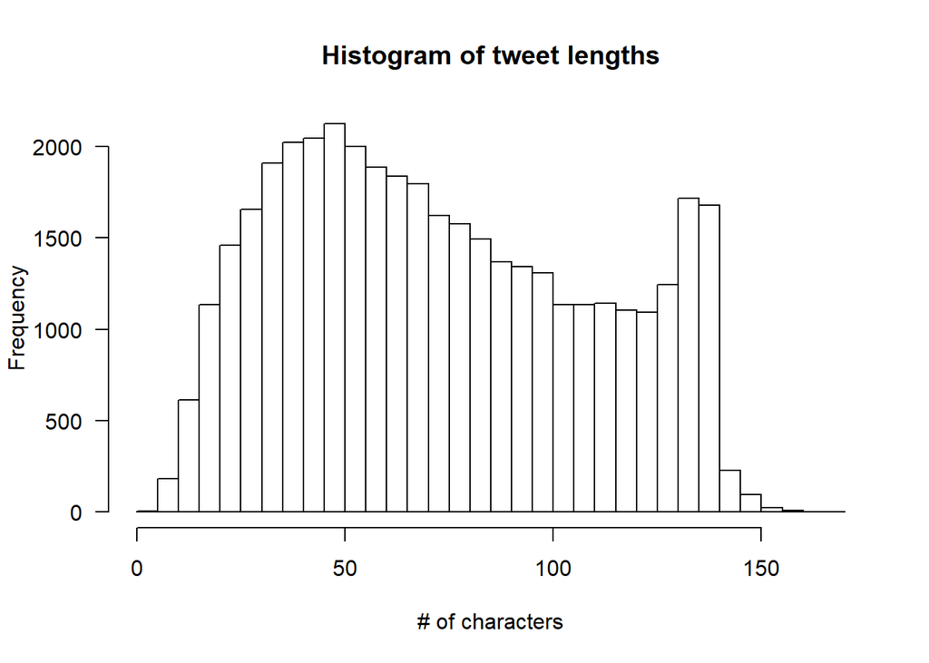

```r
hist(tweetlen,breaks = c(5*0:34), las =1,xlab = '# of characters' ,main ="Histogram of tweet lengths")
```

- Are there any tweets with 0 characters?

```r
#No tweets with 0 characters
sum(tweetlen == 0)
```

```
## [1] 0
```

- Are there any tweets with 1 character?

```r
# 4 tweets with length 1
sum(tweetlen == 1)
```

```
## [1] 4
```

```r
#contents of length 1 tweets
data$content[tweetlen == 1]
```

```
## [1] "0" "0" "0" "0"
```

```r
#positions of length 1 tweets
which(tweetlen == 1)
```

```
## [1]   341 15029 29870 39416
```

- What is the tweet with the most characters (i.e. max length)?

```r
#number of charcters for max length tweet
max(tweetlen)
```

```
## [1] 167
```

```r
#its content
data$content[which(tweetlen == max(tweetlen))]
```

```
## [1] "&quot;I'll see you again yeah?&quot; &quot;Its up to you&quot; &quot;I guarantee you will, i dont want to wait to long not seeing you&quot; fuckin fruit basket! Hahaha"
```

```r
#its location
which(tweetlen == max(tweetlen))
```

```
## [1] 34099
```

## 2) Sentiment

- What are the different types of sentiments (i.e. categories)?

```r
levels(factor(data$sentiment))
```

```
##  [1] "anger"      "boredom"    "empty"      "enthusiasm" "fun"
##  [6] "happiness"  "hate"       "love"       "neutral"    "relief"
## [11] "sadness"    "surprise"   "worry"
```

- Compute the frequencies (i.e. counts) of each sentiment

```r
table(factor(data$sentiment))
```

```
##
##      anger    boredom      empty enthusiasm        fun  happiness
##        110        179        827        759       1776       5209
##       hate       love    neutral     relief    sadness   surprise
##       1323       3842       8638       1526       5165       2187
##      worry
##       8459
```

- Graph the relative frequencies (i.e. proportions) with a horizontal barplot (bars horizontally oriented) in decreasing order, including names of sentiment types.

```r
library(ggplot2)
tbl = table(factor(data$sentiment)) / 40000
names(tbl)
```

```
##  [1] "anger"      "boredom"    "empty"      "enthusiasm" "fun"
##  [6] "happiness"  "hate"       "love"       "neutral"    "relief"
## [11] "sadness"    "surprise"   "worry"
```

```r
df = data.frame("sentiment" = sort(tbl))
df
```

```
##    sentiment.Var1 sentiment.Freq
## 1           anger       0.002750
## 2         boredom       0.004475
## 3      enthusiasm       0.018975
## 4           empty       0.020675
## 5            hate       0.033075
## 6          relief       0.038150
## 7             fun       0.044400
## 8        surprise       0.054675
## 9            love       0.096050
## 10        sadness       0.129125
## 11      happiness       0.130225
## 12          worry       0.211475
## 13        neutral       0.215950
```

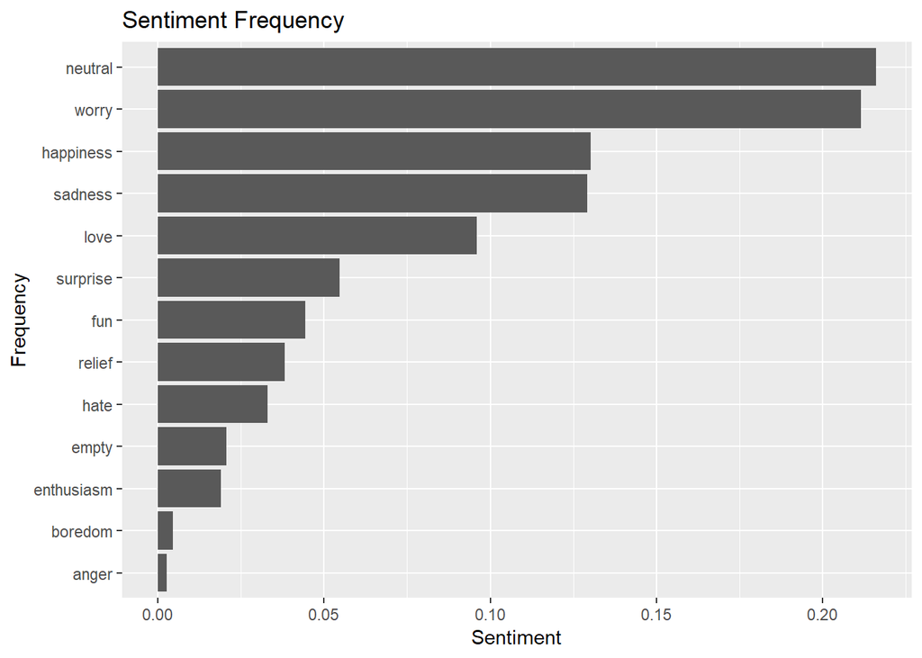

```r
ggplot(df, aes(x = sentiment.Var1, y = sentiment.Freq)) + geom_bar(stat='identity') + coord_flip() +
  labs(title = 'Sentiment Frequency', x = 'Frequency', y = 'Sentiment')
```

- Sentiment and length of tweets: compute a table with the average length of characters per sentiment (i.e. average number of characters for neutral tweets, for happy tweets, etc.). Display this table.

```r
library(dplyr)
avgtbl <- data %>% mutate('leng' = tweetlen) %>% select(sentiment, leng) %>% group_by(sentiment) %>% summarise(avg = mean(leng))

avgtbl
```

```
## # A tibble: 13 x 2
##    sentiment    avg
##    <chr>      <dbl>
##  1 anger       77.7
##  2 boredom     74.2
##  3 empty       64.6
##  4 enthusiasm  74.8
##  5 fun         81.3
##  6 happiness   75.6
##  7 hate        78.5
##  8 love        74.5
##  9 neutral     64.5
## 10 relief      76.5
## 11 sadness     75.0
## 12 surprise    75.7
## 13 worry       76.7
```

## 3) Author (usernames)

Confirm that the values in column author follow each of the rules for valid usernames: - No longer than 15 characters (if you find usernames longer than 15 characters, display them)

```r
#no username longer than 15
userlen <- nchar(data$author)
sum(userlen > 15)
```

```
## [1] 0
```

- Contain alphanumeric characters and underscores (if you find usernames containing other symbols, display them)

```r
library(stringr)

alphanum <- function(x) {
  chklist <- str_split("abcdefghijklmnopqrstuvwxyz0123456789_", '')
  y = tolower(x)

  for (i in (1:nchar(x))) {
    if (sum((substr(y, i, i) == chklist[[1]])) == 0) {
      return(FALSE)
    }
  }
  return(TRUE)
}

chk <- rep(0, 40000)
for (i in (1:40000)) {
  chk[i] = alphanum(data$author[i])
}

sum(chk)
```

```
## [1] 39999
```

```r
#there is one username with dash, not underscore
data$author[!chk]
```

```
## [1] "4040-10-01"
```

- What is the number of characters of the shortest usernames? And what are the names of these authors? (write commands to answer these questions)

```r
#shortest username has length 2
min(userlen)
```

```
## [1] 2
```

```r
#names of shortest username
data$author[which(userlen == min(userlen))]
```

```
## [1] "kk" "xz" "zk" "zk" "ms" "c5"
```

## 4) Various Symbols and Strings

- How many tweets contain at least one caret symbol “??”

```r
#40 tweets with at least one caret symbol
sum(str_detect(data$content,'\\Q^\\E'))
```

```
## [1] 40
```

- How many tweets contain three or more consecutive dollar symbols “$”

```r
#7 tweets with three or more consecutive dollar symbols
sum(grepl("\\Q$$$\\E", data$content))
```

```
## [1] 7
```

- How many tweets do NOT contain the characters “a” or “A”

```r
#1875 tweets do not contain the characters "a" or "A"
sum(!(grepl("a|A", data$content)))
```

```
## [1] 1875
```

- Display the first 10 elements of the tweets that do NOT contain the characters “a” or “A”

```r
head(data$content[!(grepl("a|A", data$content))], 10)
```

```
##  [1] "Hmmm. http://www.djhero.com/ is down"
##  [2] "Got the news"
##  [3] "I missed the bl***y bus!!!!!!!!"
##  [4] "I need skott right now"
##  [5] "I miss Voobys!"
##  [6] "i'm so tired"
##  [7] "miss 16'th"
##  [8] "my sole supporter is not my sole supporter"
##  [9] "@Emilyyy16 urgh stop it guys"
## [10] "I miss my puppy"
```

- Number of exclamation symbols “!”: compute a vector with the number of exclamation symbols in each tweet, and display its summary().

```r
exclamnum <- str_count(data$content, '!')
summary(exclamnum)
```

```
##    Min. 1st Qu.  Median    Mean 3rd Qu.    Max.
##  0.0000  0.0000  0.0000  0.5504  1.0000 76.0000
```

- What’s the tweet (content) with the largest number of exclamation symbols !? Display its content.

```r
data$content[which(exclamnum == max(exclamnum))]
```

```
## [1] "WHAHHH!!!!!!!!!!!!!!!!!!!!!!!!!!!!!!!!!!!! NOO!!!!!!!!!!!!!!!!!!!!!!!!!!!!!!!!!!!!!!!!"
```

- How many tweets contain the individual strings “omg” or “OMG” (write a command to answer this question). For example:

```r
#138 tweets with the individual strings "omg" or "OMG"
sum(grepl("^omg | omg | omg$|^OMG | OMG | OMG$", data$content))
```

```
## [1] 138
```

## 5) Table of Average Number of Patterns by Sentiment

- Write code to create (and display) a table (e.g. data frame, tibble, matrix) in which the rows correspond to the unique types of sentiments, and the columns correspond to:
1. average number of lower case letters
2. average number of upper case letters
3. average number of digits
4. average number of punctuation symbols
5. average number of spaces

```r
avgtbl2 <- data %>% mutate('lowernum' = str_count(content, "[[:lower:]]"),
                'uppernum' = str_count(content, "[[:upper:]]"),
                'digitnum' = str_count(content, "[[:digit:]]"),
                'puncnum' = str_count(content, "[[:punct:]]"),
                'spacenum' = str_count(content, "[[:space:]]")) %>%
  select(sentiment, lowernum, uppernum, digitnum, puncnum, spacenum) %>%
  group_by(sentiment) %>%
  summarise_all(mean) %>%
  rename("Avg # of lower case letters" = lowernum,
         "Avg # of uppter case letters" = uppernum,
         "Avg # of digits" = digitnum,
         "Avg # of punctuations" = puncnum,
         "Avg # of spaces" = spacenum)

avgtbl2
```

```
## # A tibble: 13 x 6
##    sentiment `Avg # of lower~ `Avg # of uppte~ `Avg # of digit~
##    <chr>                <dbl>            <dbl>            <dbl>
##  1 anger                 55.8             3.55            0.609
##  2 boredom               53.9             2.85            0.598
##  3 empty                 46.9             2.65            0.530
##  4 enthusia~             53.4             3.90            0.527
##  5 fun                   58.4             3.78            0.565
##  6 happiness             54.2             3.70            0.553
##  7 hate                  56.4             3.68            0.490
##  8 love                  53.1             3.89            0.495
##  9 neutral               46.8             2.81            0.581
## 10 relief                55.9             3.00            0.489
## 11 sadness               54.1             3.13            0.456
## 12 surprise              54.3             3.44            0.573
## 13 worry                 55.6             3.10            0.506
## # ... with 2 more variables: `Avg # of punctuations` <dbl>, `Avg # of
## #   spaces` <dbl>
```